# Milestone Report

jpanda111

May 7, 2018

### Background

##### The capstone project is to build up a prediction algorithm in natural language processing and make predictions of words utilizing the provided text data from twitter, blog and news site.

##### Basic idea is to predict the most probably next word given the prior sequence of words. The prediction will be based on N-gram model (a type of probabilistic language model for predicting the next word based on previous (n-1) words).

- Get familiar with the databases and do the necessary cleaning
- Identify appropriate tokens such as words, punctuation, and numbers.
- Remove profanity and other words do not want to predict.
- Exploratory analysis of the data, understanding the distribution of words and relationship between the words in the corpora.
- Build figures and tables to understand variation in the frequencies of words and word pairs in the data.
- Build a basic n-gram model for predicting the next word based on the previous 1, 2, 3 or (n-1) words.

##### It will also provide the summary of plans for creating the prediction algorithm and Shiny App.

### Data acquisition and cleaning

##### First, setup automatically download data and unzip it. Also downloaded necessary files for clean up.

```r
if (!file.exists("./data/final/en_US")) {
    dir.create("./data", showWarnings = FALSE)
    des <- "./data/Coursera-SwiftKey.zip"
    src <- "https://d396qusza40orc.cloudfront.net/dsscapstone/dataset/Coursera-SwiftKey.zip"
    download.file(src, des)
    unzip(des, exdir = "./data")
    rm(des, src)
    list.files()
}

if (!file.exists("./data/profanity.txt")) {
    download.file("https://www.cs.cmu.edu/~biglou/resources/bad-words.txt",
        destfile = "./data/profanity.txt")
}
```

### Exploratory analysis

##### The basic idea is to speed up the efficiency while still keep the reasonable representation of the raw data.

```r
profanity <- readLines("./data/profanity.txt", encoding = "UTF-8", skipNul = TRUE)
boguschars <- c("<U+0092>", "<U+0093>", "<U+0094>", "<U+0095>", "<U+0096>",
    "<U+0097>")

makecleancorpus <- function(data) {
    corpus <- VCorpus(VectorSource(data))
    corpus <- tm_map(corpus, content_transformer(stri_trans_tolower))
    corpus <- tm_map(corpus, PlainTextDocument)
    corpus <- tm_map(corpus, removePunctuation)
    corpus <- tm_map(corpus, removeNumbers)
    corpus <- tm_map(corpus, stripWhitespace)
    corpus <- tm_map(corpus, removeWords, stopwords("en"))
    corpus <- tm_map(corpus, removeWords, profanity)
    corpus <- tm_map(corpus, removeWords, boguschars)
    corpus <- tm_map(corpus, stripWhitespace)
    unlist(lapply(corpus, "[", "content"), use.names = FALSE)
}

# sample function from raw data
percentage = 1/50
sampledata <- function(data, percentage) {
    index <- sample(1:length(data), length(data) * percentage)
    sample_data <- data[index]
    sample_data
}

# summarise the basic data info
Summarisedata <- function(data) {
    size <- object.size(data)/1024/1024
    length <- length(data)
    words <- sum(stri_count_words(data))
    data.frame(fileSize = round(as.integer(size), digit = 2), lineCount = length,
        wordCount = words)
}
```

```r
if (!file.exists("./data/en_US.raw.RData")) {

    # import the data
    con <- file("./data/final/en_US/en_US.news.txt", open = "rb")
    news <- readLines(con, encoding = "UTF-8", skipNul = TRUE)
    close(con)
    con <- file("./data/final/en_US/en_US.blogs.txt", open = "r")
    blogs <- readLines(con, encoding = "UTF-8", skipNul = TRUE)
    close(con)
    con <- file("./data/final/en_US/en_US.twitter.txt", open = "r")
    twitter <- readLines(con, encoding = "UTF-8", skipNul = TRUE)
    close(con)
    # save temporary files inside data folder
    save(news, blogs, twitter, file = "./data/en_US.raw.RData", compress = TRUE,
        ascii = FALSE)
} else {
    load("./data/en_US.raw.RData")
}

if (!file.exists("./data/en_US.sample.RData")) {

    # sample the data
    sample_blogs <- sampledata(blogs, percentage)
    sample_twitter <- sampledata(twitter, percentage)
    sample_news <- sampledata(news, percentage)
    sample_total <- c(sample_blogs, sample_twitter, sample_news)
    # save temporary files inside data folder
    save(sample_blogs, sample_twitter, sample_news, sample_total, Summary, file = "./data/en_US.sample.RData",
        compress = TRUE, ascii = FALSE)
} else {
    load("./data/en_US.sample.RData")
}

if (!file.exists("./data/en_US.corpus.RData")) {

    # make a clean corpus data
    blogsCorpus <- makecleancorpus(sample_blogs)
    twitterCorpus <- makecleancorpus(sample_twitter)
    newsCorpus <- makecleancorpus(sample_news)
    totalCorpus <- makecleancorpus(sample_total)

    # explore the basic data info
    newsinfo <- Summarisedata(news)
    blogsinfo <- Summarisedata(blogs)
    twitterinfo <- Summarisedata(twitter)
    samplenewsinfo <- Summarisedata(sample_news)
    sampleblogsinfo <- Summarisedata(sample_blogs)
    sampletwitterinfo <- Summarisedata(sample_twitter)
    sampletotalinfo <- Summarisedata(sample_total)
    Summary <- data.frame(fileName = c("News", "Blogs", "Twitter", "Sample News",
        "Sample Blogs", "Sample Twitter", "Sample Total"), rbind(newsinfo, blogsinfo,
        twitterinfo, samplenewsinfo, sampleblogsinfo, sampletwitterinfo, sampletotalinfo))
    colnames(Summary) <- c("File Name", "File Size in Megabyte", "Line Count",
        "Word Count")

    # save temporary files inside data folder
    save(blogsCorpus, twitterCorpus, newsCorpus, totalCorpus, file = "./data/en_US.corpus.RData",
        compress = TRUE, ascii = FALSE)
} else {
    load("./data/en_US.corpus.RData")
}
```

### Statistical modeling

##### Build up functions to find most frequency occuring words in the data. Use parameter n to determine different models such as uni-grams, bi-grams, and tri-grams. Also save temporary file into workspace for reproducible research.

```r
# Functions to build up n-grams statistical models, return a data frame with
# sorted frequency
NGramModel <- function(data, n) {
    if (n == 1) {
        token <- WordTokenizer(data)
    } else {
        token <- NGramTokenizer(data, Weka_control(min = n, max = n))
    }
    freq <- data.frame(table(token))
    sortfreq <- freq[order(freq$Freq, decreasing = TRUE), ]
    sortfreq
}
```

### Explorary Plots

##### Based on the statistical model we built, we can get frequencies of most common n-grams words in data sample.

##### Plot the distribution of most common words to understand the relationship between the words in the corpora.

```r
cnt <- 1:100
data <- data.frame(words_blogs = NGramModel(blogsCorpus, 1)[cnt, ]$token, freq_blogs = NGramModel(blogsCorpus,
    1)[cnt, ]$Freq)
data <- cbind(data, data.frame(words_news = NGramModel(newsCorpus, 1)[cnt, ]$token,
    freq_news = NGramModel(newsCorpus, 1)[cnt, ]$Freq))
data <- cbind(data, data.frame(words_twitter = NGramModel(twitterCorpus, 1)[cnt,
    ]$token, freq_twitter = NGramModel(twitterCorpus, 1)[cnt, ]$Freq))
data <- cbind(data, data.frame(words_total = NGramModel(totalCorpus, 1)[cnt,
    ]$token, freq_total = NGramModel(totalCorpus, 1)[cnt, ]$Freq))
head(data, 10)
```

```
   words_blogs freq_blogs words_news freq_news words_twitter freq_twitter
1          one       2369       said      4960            im         3083
2         will       2173       will      2258          just         3005
3         like       1979        one      1705          like         2453
4         just       1966        new      1440           get         2162
5          can       1859        can      1236          love         2145
6         time       1730        two      1142          good         2023
7           s       1593       year      1125          will         1893
8          get       1473       also      1120            rt         1803
9          now       1297       just      1115           can         1772
10        know       1201       last      1085           day         1758
   words_total freq_total
1         will       6324
2         just       6086
3         said       6070
4          one       5652
5         like       5448
6          can       4867
7          get       4514
8         time       4271
9           im       4207
10         new       3857
```

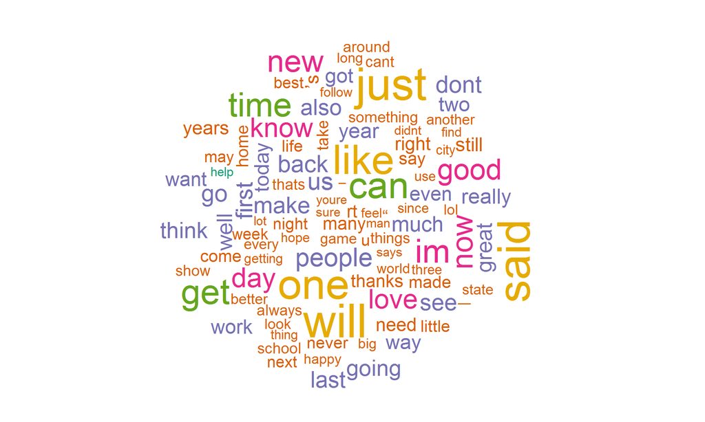

```r
suppressWarnings(wordcloud(data$words_total, data$freq_total, max.words = 100,
    colors = brewer.pal(6, "Dark2")))
```

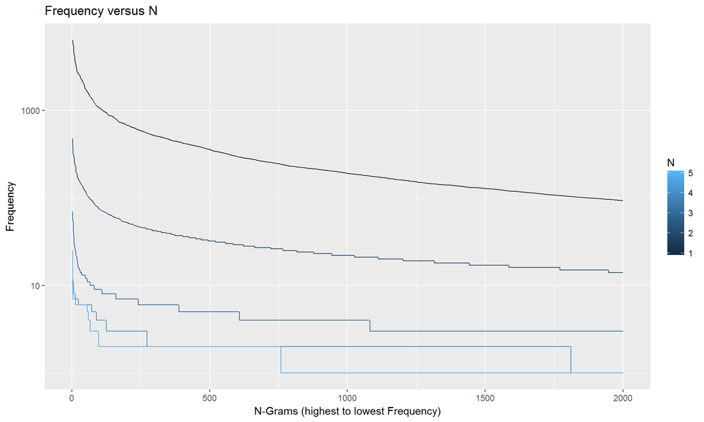

```r
cnt <- 1:2000
data <- data.frame()
data <- rbind(data, data.frame(Freq = NGramModel(totalCorpus, 1)[cnt, ]$Freq,
    N = 1, Index = cnt))
data <- rbind(data, data.frame(Freq = NGramModel(totalCorpus, 2)[cnt, ]$Freq,
    N = 2, Index = cnt))
data <- rbind(data, data.frame(Freq = NGramModel(totalCorpus, 3)[cnt, ]$Freq,
    N = 3, Index = cnt))
data <- rbind(data, data.frame(Freq = NGramModel(totalCorpus, 4)[cnt, ]$Freq,
    N = 4, Index = cnt))
data <- rbind(data, data.frame(Freq = NGramModel(totalCorpus, 5)[cnt, ]$Freq,
    N = 5, Index = cnt))

ggplot(data, aes(x = Index, y = Freq, group = N, color = N)) + geom_line() +
    xlab("N-Grams (highest to lowest Frequency)") + ylab("Frequency") + ggtitle("Frequency versus N") +
    scale_y_log10()
```

### Future Work

##### After producing the N-gram based statistical model, here is a brief summary for the future work.

- Improve current model to handle out-of-vocabulary words issue so we can still do prediction when N-1 previous words are not present.
- Build up prediction models and evaluate for efficiency and accuracy.
- Fine-tune model, improve the computation performance, and save the memory.
- Create a Shiny application
- Generate slide presentation pitching the product